# R markdown assignment

Kyagulanyi Ali

6/25/2021

# Question 1

Import the data described above into R, provide descriptive summaries of the subject data (using appropriate graphics and statistical summary measures) given in the diabimmune_16s_t1d_metadata.csv file. In addition, use appropriate test(s) to check for association/independency between disease status and other variables (delivery mode, gender and age). Note that age is given in days.

```r
## Load the required packages
library(tidyverse)
library(phyloseq)
```

```r
sample_metadata <- read.csv("diabimmune_16s_t1d_metadata (1).csv", sep = ",", header = T) # import sample data
# Explore the data and have a glimpse of it
head(sample_metadata)
```

```
##   ï..Sample_ID Subject_ID Case_Control Gender Delivery_Route Age_at_Collection
## 1       G36449    E001463      control   male        vaginal                62
## 2       G36034    E001463      control   male        vaginal                82
## 3       G36993    E001463      control   male        vaginal               124
## 4       G35523    E001463      control   male        vaginal               153
## 5       G36450    E001463      control   male        vaginal               187
## 6       G36028    E001463      control   male        vaginal               213
```

```r
tail(sample_metadata)
```

```
##     ï..Sample_ID Subject_ID Case_Control Gender Delivery_Route
## 772       G36938    T026177      control female        vaginal
## 773       G36936    T026177      control female        vaginal
## 774       G36937    T026177      control female        vaginal
## 775       G35535    T026177      control female        vaginal
## 776       G35536    T026177      control female        vaginal
## 777       G35537    T026177      control female        vaginal
##     Age_at_Collection
## 772               570
## 773               592
## 774               646
## 775               677
## 776               703
## 777               729
```

```r
dim(sample_metadata)
```

```
## [1] 777   6
```

## How many were cases and controls

```r
case_control_count <- sample_metadata %>%
  group_by(Case_Control) %>%
  summarise(Total = n(), Percentage = (Total / 777) * 100)
case_control_count
```

```
## # A tibble: 2 x 3
##   Case_Control Total Percentage
##   <chr>        <int>      <dbl>
## 1 case           260       33.5
## 2 control        517       66.5
```

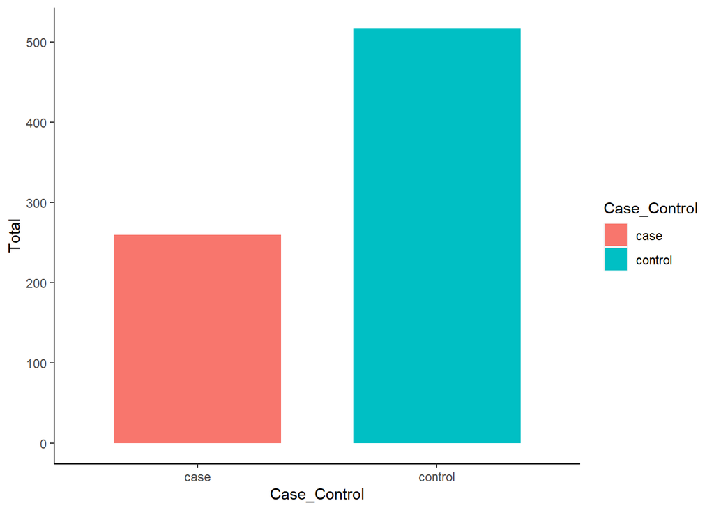

```r
ggplot(case_control_count, aes(x = Case_Control, y = Total, fill = Case_Control)) +
  geom_bar(stat = "identity", width = 0.7) +
  theme(panel.grid.major = element_blank(), panel.grid.minor = element_blank(),
        panel.background = element_blank(), axis.line = element_line(colour = "black"))
```

## How many were males and females

```r
gender_counts <- sample_metadata %>%
  group_by(Gender) %>%
  summarise(Total = n(), Percentage = (Total / 777) * 100)
gender_counts
```

```
## # A tibble: 2 x 3
##   Gender Total Percentage
##   <chr>  <int>      <dbl>
## 1 female   412       53.0
## 2 male     365       47.0
```

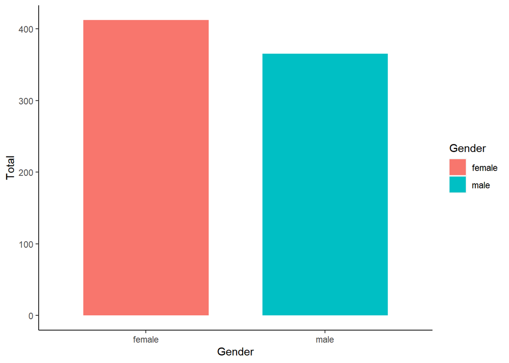

```r
ggplot(gender_counts, aes(x = Gender, y = Total, fill = Gender)) +
  geom_bar(stat = "identity", width = 0.7) +
  theme(panel.grid.major = element_blank(), panel.grid.minor = element_blank(),
        panel.background = element_blank(), axis.line = element_line(colour = "black"))
```

## How many fall into each delivery route

```r
delivery_route_count <- sample_metadata %>%
  group_by(Delivery_Route) %>%
  summarise(Total = n(), Percentage = (Total / nrow(sample_metadata)) * 100)
delivery_route_count
```

```
## # A tibble: 2 x 3
##   Delivery_Route Total Percentage
##   <chr>          <int>      <dbl>
## 1 cesarian          66       8.49
## 2 vaginal          711      91.5
```

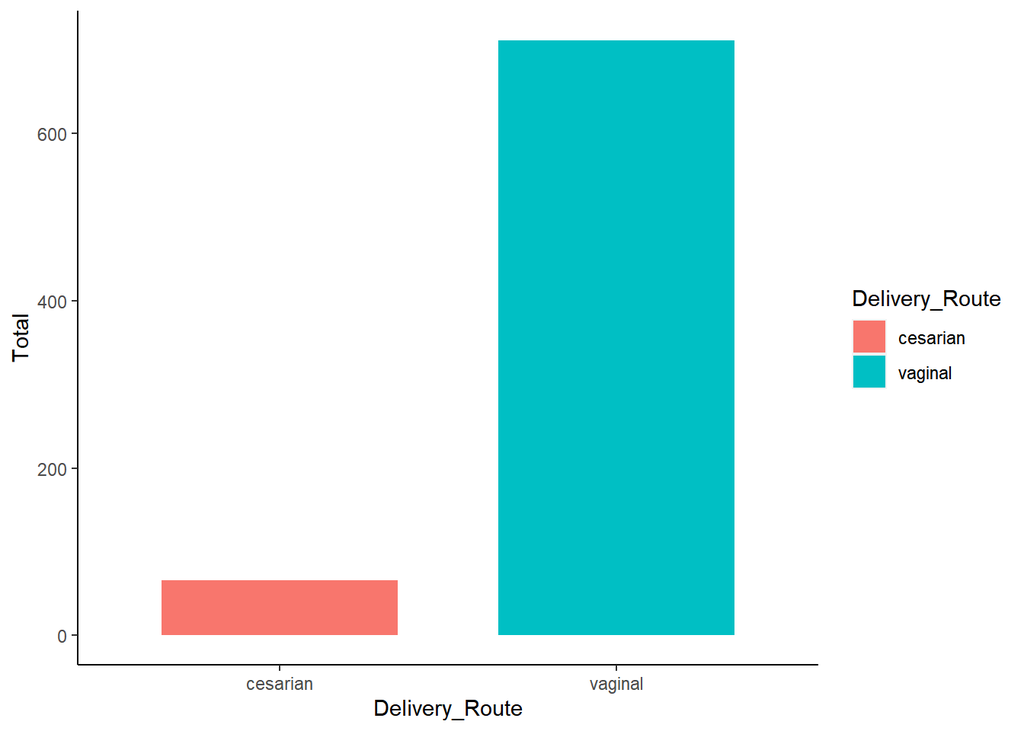

```r
ggplot(delivery_route_count, aes(x = Delivery_Route, y = Total, fill = Delivery_Route)) +
  geom_bar(stat = "identity", width = 0.7) +
  theme(panel.grid.major = element_blank(), panel.grid.minor = element_blank(),
        panel.background = element_blank(), axis.line = element_line(colour = "black"))
```

## Cases and controls versus gender

```r
status_gender <- sample_metadata %>%
  group_by(Gender, Case_Control) %>%
  summarise(Total = n(), Percentage = (Total / nrow(sample_metadata)) * 100)
status_gender
```

```
## # A tibble: 4 x 4
## # Groups:   Gender [2]
##   Gender Case_Control Total Percentage
##   <chr>  <chr>        <int>      <dbl>
## 1 female case           142       18.3
## 2 female control        270       34.7
## 3 male   case           118       15.2
## 4 male   control        247       31.8
```

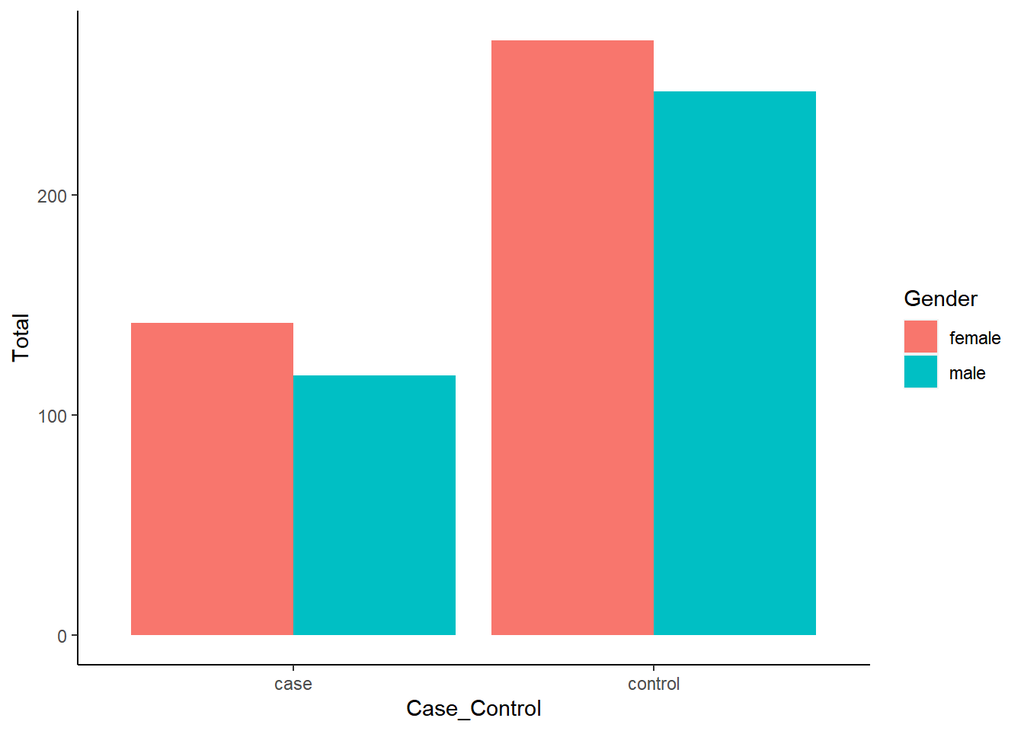

```r
ggplot(status_gender, aes(fill=Gender, y=Total, x=Case_Control)) +
  geom_bar(position="dodge", stat="identity") +
  theme(panel.grid.major = element_blank(), panel.grid.minor = element_blank(),
        panel.background = element_blank(), axis.line = element_line(colour = "black"))
```

### Relationship between status and gender

Here we use the chi-square test to determine whether the status and gender are independent or dependent of each other.

Null hypothesis: Status and gender are independent

Alternate hypothesis: Status and gender relate to each other Note: We set our significance level at 0.05. So, if we get a p-value less than 0.05, we shall reject the null hypothesis, otherwise, we fail to reject it.

```r
female <- c(142, 270)
male <- c(118, 247)
gen_mat <- cbind(female, male)
row.names(gen_mat) <- c("case", "control")
chisq.test(gen_mat)
```

```
##
##  Pearson's Chi-squared test with Yates' continuity correction
##
## data:  gen_mat
## X-squared = 0.30687, df = 1, p-value = 0.5796
```

## Cases and controls versus delivery route

```r
status_route <- sample_metadata %>%
  group_by(Case_Control, Delivery_Route) %>%
  summarise(Total = n(), Percentage = (Total / nrow(sample_metadata)) * 100)
status_route
```

```
## # A tibble: 3 x 4
## # Groups:   Case_Control [2]
##   Case_Control Delivery_Route Total Percentage
##   <chr>        <chr>          <int>      <dbl>
## 1 case         vaginal          260      33.5
## 2 control      cesarian          66       8.49
## 3 control      vaginal          451      58.0
```

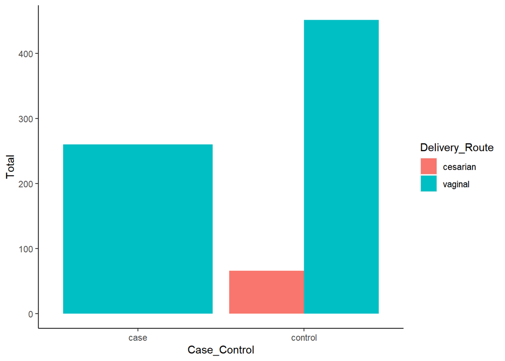

```r
ggplot(status_route, aes(fill=Delivery_Route, y=Total, x=Case_Control)) +
  geom_bar(position="dodge", stat="identity") +
  theme(panel.grid.major = element_blank(), panel.grid.minor = element_blank(),
        panel.background = element_blank(), axis.line = element_line(colour = "black"))
```

### Relationship between status and delivery route

Here we use the chi-square test to determine whether the status and delivery routes are independent or dependent of each other.

Null hypothesis: Status and delivery route are independent

Alternate hypothesis: Status and delivery route relate to each other Note: We set our significance level at 0.05. So, if we get a p-value less than 0.05, we shall reject the null hypothesis, otherwise, we fail to reject it.

```r
vaginal <- c(260, 451)
cesarian <- c(0, 66)
del_mat <- cbind(vaginal, cesarian)
row.names(del_mat) <- c("case", "control")
chisq.test(del_mat)
```

```
##
##  Pearson's Chi-squared test with Yates' continuity correction
##
## data:  del_mat
## X-squared = 34.649, df = 1, p-value = 3.949e-09
```

## Cases and controls, gender plus delivery route

```r
status_gender_delivery <- sample_metadata %>%
  group_by(Gender, Case_Control, Delivery_Route) %>%
  summarise(Total = n(), Percentage = (Total / nrow(sample_metadata)) * 100)
status_gender_delivery
```

```
## # A tibble: 6 x 5
## # Groups:   Gender, Case_Control [4]
##   Gender Case_Control Delivery_Route Total Percentage
##   <chr>  <chr>        <chr>          <int>      <dbl>
## 1 female case         vaginal          142      18.3
## 2 female control      cesarian          38       4.89
## 3 female control      vaginal          232      29.9
## 4 male   case         vaginal          118      15.2
## 5 male   control      cesarian          28       3.60
## 6 male   control      vaginal          219      28.2
```

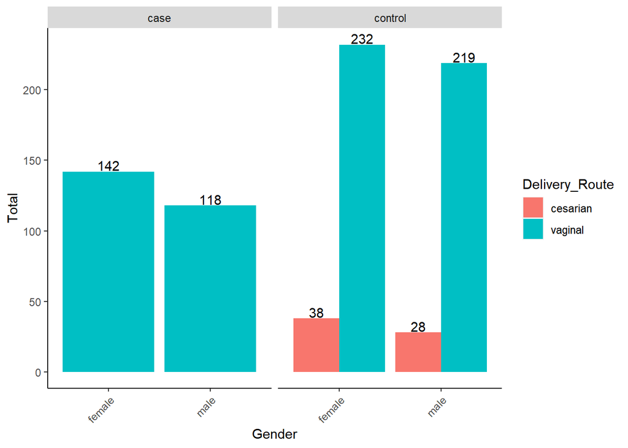

```r
p <- ggplot(status_gender_delivery, aes(x = Gender, y = Total, fill = Delivery_Route)) +
  geom_bar(position="dodge", stat="identity") +
  theme(panel.grid.major = element_blank(),
        panel.grid.minor = element_blank(), panel.background = element_blank(), axis.line =
          element_line(colour = "black"), axis.text.x = element_text(angle = 45, hjust = 1))
p + facet_grid(. ~ Case_Control) + geom_text(aes(label = Total), vjust = -0.1, position =
      position_dodge(width = 0.9)) +
        labs(x = "Gender")
```

# Question 2 Using phyloseq, create a phyloseq object. This will comprise the OTU abundance, taxonomy (provided in the .txt file) and sample data (provided in the .csv file)

```r
# import otu table
otut <- read.table("otu_table")
head(otut, n = 1)
```

[output not shown]

[output cut: 101 more lines]

[output not shown]

```r
# import taxa table
taxat <- read.table("new_taxa_table")
head(taxat)
```

```
##               Domain.            Phylum.                  Class.
## 4333897; k__Bacteria; p__Proteobacteria; c__Gammaproteobacteria;
## 190162;  k__Bacteria;     p__Firmicutes;          c__Clostridia;
## 134726;  k__Bacteria;     p__Firmicutes;             c__Bacilli;
## 679245;  k__Bacteria;     p__Firmicutes;             c__Bacilli;
## 289734;  k__Bacteria;     p__Firmicutes;          c__Clostridia;
## 302049;  k__Bacteria;     p__Firmicutes;          c__Clostridia;
##                         Order.                Family.            Genus. Species
## 4333897; o__Enterobacteriales; f__Enterobacteriaceae;              g__;     s__
## 190162;      o__Clostridiales;    f__Lachnospiraceae;       g__Blautia;     s__
## 134726;    o__Lactobacillales;   f__Lactobacillaceae; g__Lactobacillus;     s__
## 679245;    o__Lactobacillales;   f__Lactobacillaceae; g__Lactobacillus;     s__
## 289734;      o__Clostridiales;    f__Lachnospiraceae;              g__;     s__
## 302049;      o__Clostridiales;    f__Lachnospiraceae;       g__Blautia;     s__
```

```r
#dim(taxat)
#dim(otut)
#class(taxat)
#class(otut)
# convert the otu table into a matrix
otut_mat <- as.matrix(otut)
class(otut_mat)
```

```
## [1] "matrix" "array"
```

```r
# convert the taxa table into a matrix
taxat_mat <- as.matrix(taxat)
class(taxat_mat)
```

```
## [1] "matrix" "array"
```

```r
#head(taxat_mat)
# remove ; from the columns of taxa table
taxat_mat_sub <- gsub(";", "", taxat_mat)
#head(taxat_mat_sub)
# Our row names are ending with ; and this makes them different from the naming in the otu table
# so we need to remove the ;
# extract the rownames and store them in the mat_names object
mat_names <- row.names(taxat_mat_sub)
# remove ; from the mat_names and store them to new_naam
new_naam <- gsub(";", "", mat_names)
#new_naam
# now change the row names of taxat_mat_sub to the names in "new_naam
row.names(taxat_mat_sub) <- new_naam
library(phyloseq)
OTU <- otu_table(otut_mat, taxa_are_rows = TRUE)
TAX <- tax_table(taxat_mat_sub)
#OTU
#TAX
?column_to_rownames
```

```
## starting httpd help server ... done
```

```r
library("phyloseq")
head(sample_metadata)
```

```
##   ï..Sample_ID Subject_ID Case_Control Gender Delivery_Route Age_at_Collection
## 1       G36449    E001463      control   male        vaginal                62
## 2       G36034    E001463      control   male        vaginal                82
## 3       G36993    E001463      control   male        vaginal               124
## 4       G35523    E001463      control   male        vaginal               153
## 5       G36450    E001463      control   male        vaginal               187
## 6       G36028    E001463      control   male        vaginal               213
```

```r
samp_data <- column_to_rownames(sample_metadata, var = "ï..Sample_ID")
samp_data <- sample_data(samp_data)
physeq <- phyloseq(OTU, TAX, samp_data)
physeq
```

```
## phyloseq-class experiment-level object
## otu_table()   OTU Table:         [ 2240 taxa and 777 samples ]
## sample_data() Sample Data:       [ 777 samples by 5 sample variables ]
## tax_table()   Taxonomy Table:    [ 2240 taxa by 7 taxonomic ranks ]
```

# Question 3

## Alpha diversity comparing the gender in cases and controls

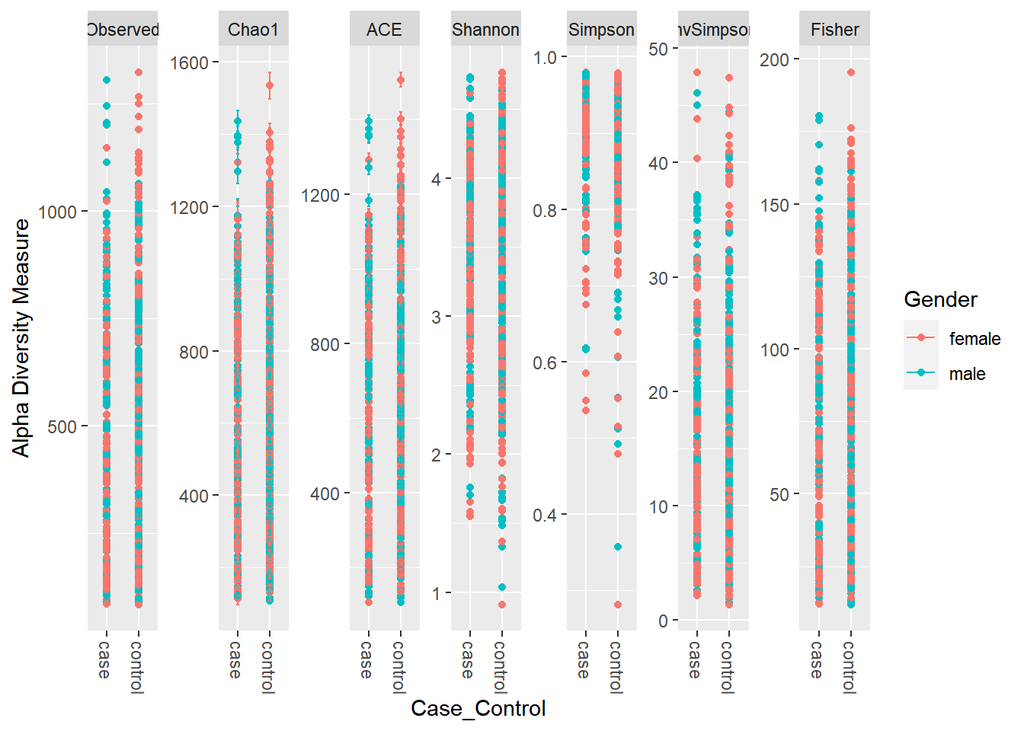

```r
plot_richness(physeq = physeq, x = "Case_Control", color = "Gender")
```

## Alpha diversity comparing the delivery routes in cases and controls

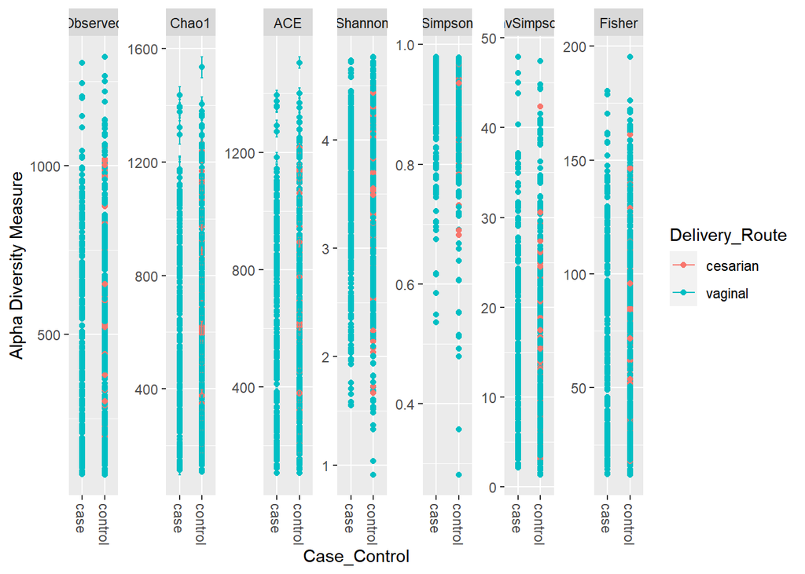

```r
plot_richness(physeq = physeq, x = "Case_Control", color = "Delivery_Route")
```

# Question 4 Perform differential abundance using DEseq2

```r
library(DESeq2)
diagdds = phyloseq_to_deseq2(physeq, ~ Case_Control)
# calculate geometric means prior to estimate size factors
gm_mean = function(x, na.rm=TRUE){
  exp(sum(log(x[x > 0]), na.rm=na.rm) / length(x))
}
geoMeans = apply(counts(diagdds), 1, gm_mean)
diagdds = estimateSizeFactors(diagdds, geoMeans = geoMeans)
diagdds = DESeq(diagdds, fitType="local")
```

```
## -- replacing outliers and refitting for 1151 genes
## -- DESeq argument 'minReplicatesForReplace' = 7
## -- original counts are preserved in counts(dds)
```

```r
res = results(diagdds, cooksCutoff = FALSE)
alpha = 0.01
sigtab = res[which(res$padj < alpha), ]
sigtab = cbind(as(sigtab, "data.frame"), as(tax_table(physeq)[rownames(sigtab), ], "matrix"))
head(sigtab)
```

```
##            baseMean log2FoldChange     lfcSE      stat       pvalue
## 134726     5.650900       2.131322 0.5665873  3.761684 1.687732e-04
## 193672    91.723631       1.574409 0.2337252  6.736154 1.626344e-11
## 4439360 1081.732052       1.293402 0.2627492  4.922573 8.541366e-07
## 306299     7.927932       1.012594 0.2723463  3.718038 2.007759e-04
## 1142029   25.917987      -1.281228 0.2383396 -5.375638 7.631189e-08
## 4372612   14.952956       1.153458 0.2793272  4.129415 3.636874e-05
##                 padj     Domain.           Phylum.            Class.
## 134726  1.740775e-03 k__Bacteria     p__Firmicutes        c__Bacilli
## 193672  1.174221e-09 k__Bacteria     p__Firmicutes     c__Clostridia
## 4439360 1.932538e-05 k__Bacteria  p__Bacteroidetes    c__Bacteroidia
## 306299  2.013336e-03 k__Bacteria     p__Firmicutes     c__Clostridia
## 1142029 2.648903e-06 k__Bacteria p__Actinobacteria c__Actinobacteria
## 4372612 4.935757e-04 k__Bacteria  p__Bacteroidetes    c__Bacteroidia
##                       Order.               Family.             Genus. Species
## 134726    o__Lactobacillales   f__Lactobacillaceae   g__Lactobacillus     s__
## 193672      o__Clostridiales     f__Clostridiaceae                g__     s__
## 4439360     o__Bacteroidales     f__Bacteroidaceae     g__Bacteroides     s__
## 306299      o__Clostridiales    f__Lachnospiraceae                g__     s__
## 1142029 o__Bifidobacteriales f__Bifidobacteriaceae g__Bifidobacterium     s__
## 4372612     o__Bacteroidales     f__Bacteroidaceae     g__Bacteroides     s__
```

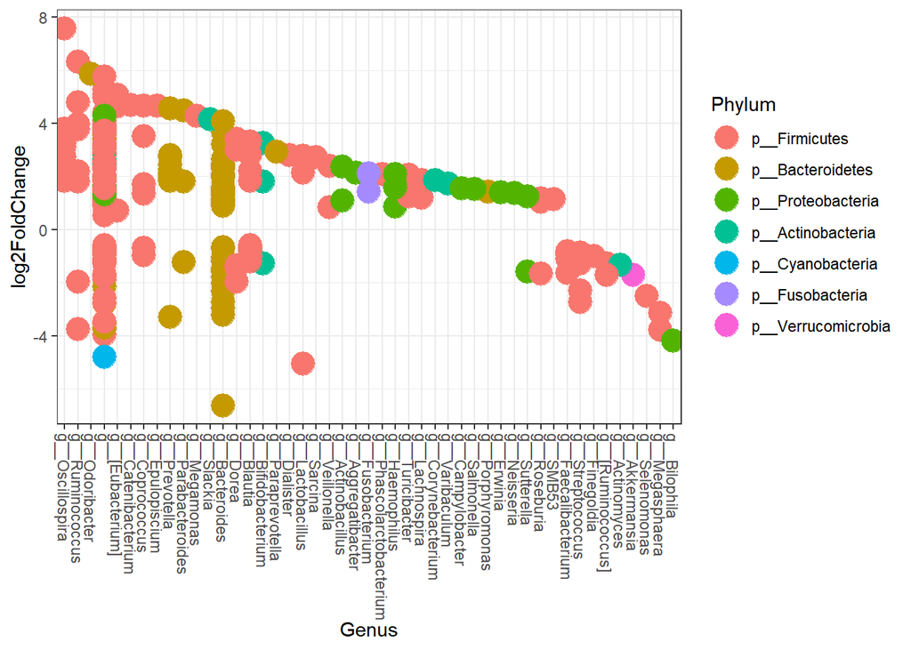

```r
# library("ggplot2")
theme_set(theme_bw())
scale_fill_discrete <- function(palname = "Set1", ...) {
    scale_fill_brewer(palette = palname, ...)
}
# Phylum order
x = tapply(sigtab$log2FoldChange, sigtab$Phylum, function(x) max(x))
x = sort(x, TRUE)
sigtab$Phylum = factor(as.character(sigtab$Phylum), levels=names(x))
# Genus order
x = tapply(sigtab$log2FoldChange, sigtab$Genus, function(x) max(x))
x = sort(x, TRUE)
sigtab$Genus = factor(as.character(sigtab$Genus), levels=names(x))
ggplot(sigtab, aes(x=Genus, y=log2FoldChange, color=Phylum)) + geom_point(size=6) +
  theme(axis.text.x = element_text(angle = -90, hjust = 0, vjust=0.5))
```